# R Notebook

# Assignment 7

```r
library(faraway)
data(uswages)
```

# Exercise 1

1. Create factors, remove NAs

```r
head(uswages)
```

```
##         wage educ exper race smsa ne mw so we pt
## 6085  771.60   18    18    0    1  1  0  0  0  0
## 23701 617.28   15    20    0    1  0  0  0  1  0
## 16208 957.83   16     9    0    1  0  0  1  0  0
## 2720  617.28   12    24    0    1  1  0  0  0  0
## 9723  902.18   14    12    0    1  0  1  0  0  0
## 22239 299.15   12    33    0    1  0  0  0  1  0
```

```r
# we see that exper has neg. values
uswages$exper[uswages$exper <0] <-NA
uswages$wage[uswages$wage ==0] <-NA
uswages<- na.omit(uswages)
dim(uswages)
```

```
## [1] 1967   10
```

```r
#Creating factors
uswages$race<- factor(uswages$race)
uswages$smsa <- factor(uswages$smsa)
uswages$pt <- factor(uswages$pt)
```

2. Process the data to make factors with named levels for race, smsa, and pt.

```r
#Creating levels
levels(uswages$race)<- c("White","Black")
levels(uswages$smsa)<- c("No","Yes")
levels(uswages$pt)<-c("No","Yes")
```

3. Replace the indicator variables ne, mw, so, and we with one factor called region with levels named: ne, mw, so, and we*.

```r
uswages <- data.frame(uswages,
                      region =
                        1*uswages$ne +
                        2*uswages$mw +
                        3*uswages$so +
                        4*uswages$we)
uswages$region <- factor(uswages$region)
levels(uswages$region) <- c("ne","mw","so","we")
```

4. Remove all NAs.

```r
uswages<- na.omit(uswages)
dim(uswages)
```

```
## [1] 1967   11
```

# Excercise 2

Show that the summary of your final data is the following.

```r
#We use subset function to remove unnecessary variable
uswages <- subset(uswages,select=-c(ne:mw:so:we))
summary(uswages)
```

```
##       wage              educ           exper          race       smsa
##  Min.   :  50.39   Min.   : 0.00   Min.   : 0.00   White:1812   No : 483
##  1st Qu.: 314.69   1st Qu.:12.00   1st Qu.: 8.00   Black: 155   Yes:1484
##  Median : 522.32   Median :12.00   Median :16.00
##  Mean   : 613.99   Mean   :13.08   Mean   :18.74
##  3rd Qu.: 783.48   3rd Qu.:16.00   3rd Qu.:27.00
##  Max.   :7716.05   Max.   :18.00   Max.   :59.00
##    pt       region
##  No :1802   ne:448
##  Yes: 165   mw:488
##             so:616
##             we:415
##
##
```

# Exercise 3

1. Compute OLS fit to model log(wage)~.

```r
pred1 <- lm(log(wage)~.,data=uswages)

summary(pred1)
```

```
##
## Call:
## lm(formula = log(wage) ~ ., data = uswages)
##
## Residuals:
##     Min      1Q  Median      3Q     Max
## -2.5158 -0.3309  0.0504  0.3520  3.9446
##
## Coefficients:
##              Estimate Std. Error t value Pr(>|t|)
## (Intercept)  4.710039   0.076052  61.932  < 2e-16 ***
## educ         0.087515   0.004494  19.472  < 2e-16 ***
## exper        0.015483   0.001016  15.243  < 2e-16 ***
## raceBlack   -0.215273   0.048723  -4.418 1.05e-05 ***
## smsaYes      0.177741   0.030177   5.890 4.54e-09 ***
## ptYes       -1.067418   0.046344 -23.032  < 2e-16 ***
## regionmw     0.008320   0.037489   0.222    0.824
## regionso     0.010080   0.035945   0.280    0.779
## regionwe     0.046846   0.038922   1.204    0.229
## ---
## Signif. codes:  0 '***' 0.001 '**' 0.01 '*' 0.05 '.' 0.1 ' ' 1
##
## Residual standard error: 0.5686 on 1958 degrees of freedom
## Multiple R-squared:  0.368,  Adjusted R-squared:  0.3654
## F-statistic: 142.5 on 8 and 1958 DF,  p-value: < 2.2e-16
```

2. Perform the Shapiro-Wilk Test of Normality for the residuals, what is the conclusion?

```r
shapiro.test(residuals(pred1))
```

```
##
##  Shapiro-Wilk normality test
##
## data:  residuals(pred1)
## W = 0.96353, p-value < 2.2e-16
```

```r
car::durbinWatsonTest(residuals(pred1))
```

```
## [1] 2.019196
```

```r
car::vif(pred1)
```

```
##            GVIF Df GVIF^(1/(2*Df))
## educ   1.114749  1        1.055817
## exper  1.100628  1        1.049108
## race   1.048380  1        1.023904
## smsa   1.026374  1        1.013101
## pt     1.004126  1        1.002061
## region 1.061190  3        1.009948
```

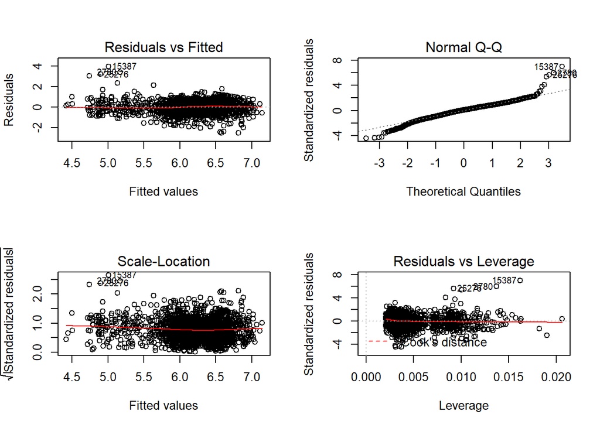

```r
par(mfrow = c(2, 2))
plot(pred1)
```

Conclusion:

1. In the four plots , we can observe that there is no sinusoidal pattern against the fitted values which indicates that residuals are independent.
2. Also, Null Hypothesis is getting rejected as P-value is less than 0.05(value is 2.2 e-16) for Shapiro-Wilk Test. Hence Residuals are not normal.

# Exercise 4

1. Compute WLS fit to model log(wage)~. and weights = 1/(1+educ)

```r
library(car)
pred2 <- lm(log(wage) ~., uswages, weight = 1/(1+educ))
compareCoefs(pred2, pred1)
```

```
##
## Call:
## 1: lm(formula = log(wage) ~ ., data = uswages, weights = 1/(1 + educ))
## 2: lm(formula = log(wage) ~ ., data = uswages)
##               Est. 1     SE 1   Est. 2     SE 2
## (Intercept)  5.09109  0.07222  4.71004  0.07605
## educ         0.06452  0.00379  0.08751  0.00449
## exper        0.01334  0.00108  0.01548  0.00102
## raceBlack   -0.23117  0.05123 -0.21527  0.04872
## smsaYes      0.21574  0.03282  0.17774  0.03018
## ptYes       -1.00095  0.05139 -1.06742  0.04634
## regionmw    -0.07210  0.04215  0.00832  0.03749
## regionso    -0.06874  0.03958  0.01008  0.03595
## regionwe    -0.08841  0.04271  0.04685  0.03892
```

2. Perform the Shapiro-Wilk Test of Normality for the residuals, what is the conclusion?

```r
par(mfrow = c(1, 1))
shapiro.test(residuals(pred2))
```

```
##
##  Shapiro-Wilk normality test
##
## data:  residuals(pred2)
## W = 0.972, p-value < 2.2e-16
```

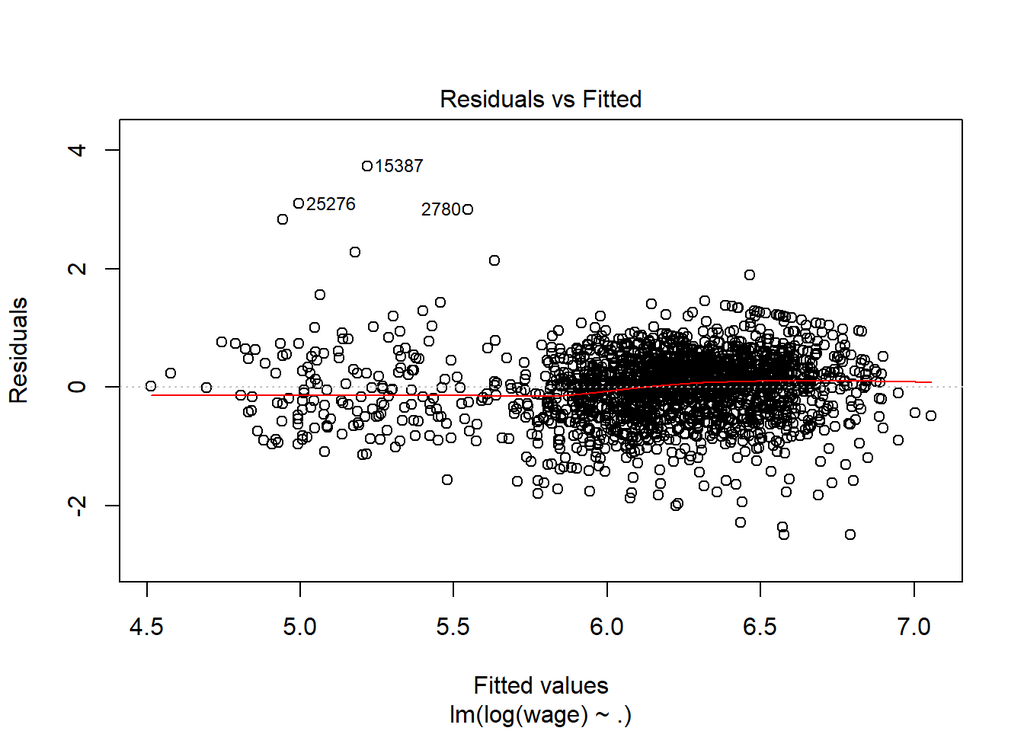

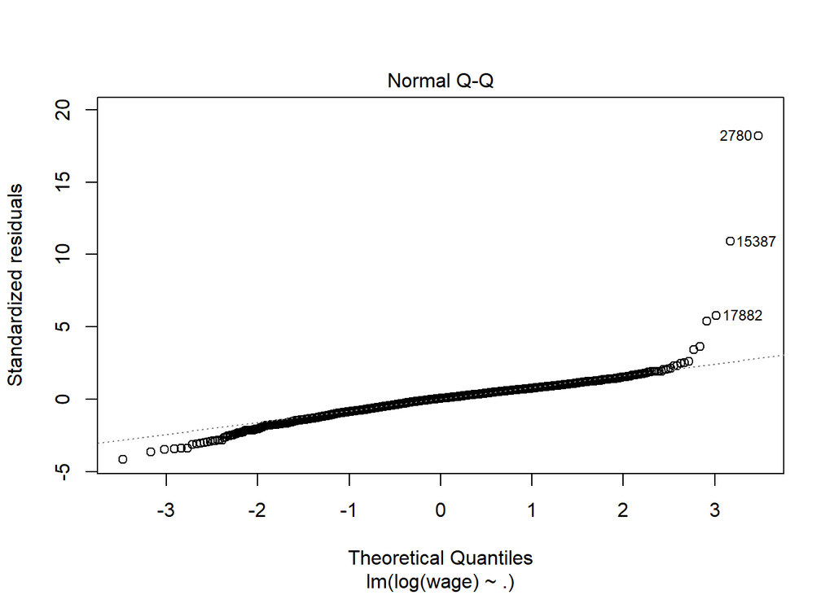

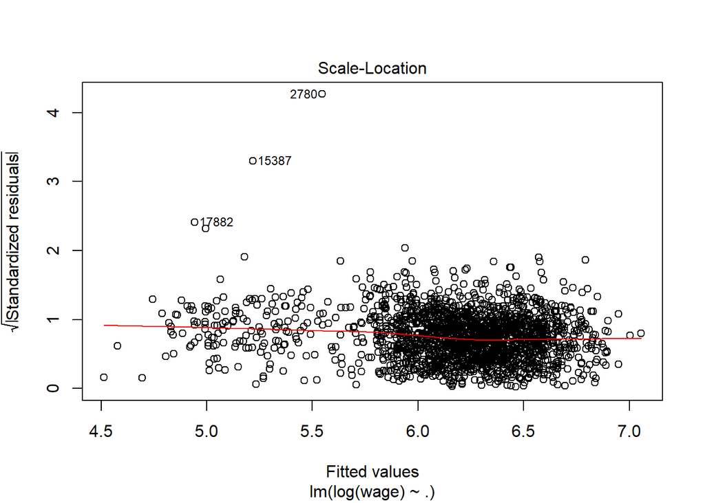

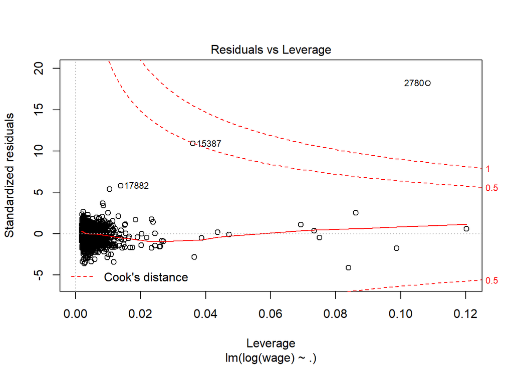

```r
plot(pred2)
```

Conclusion:

1. In the four plots , we can observe that there is no sinusoidal pattern against the fitted values which indicates that residuals are independent.
2. Also, Null Hypothesis is getting rejected as P-value is less than 0.05(value is 2.2 e-16) for Shapiro-Wilk Test. Hence Residuals are not normal.